# Leadership LCA - Part 2: effect modification of covariate associations by sample (general vs hospital)

Author

Andres Gonzalez Santa Cruz

Published

July 4, 2026

# What this notebook does (Part 2)

Part 1 (`leadership_LCA_analysis.qmd`) retained **four** latent leadership profiles in the general salaried-worker survey and related profile membership to covariates with a bias-adjusted **ML three-step** estimator, reporting the odds ratios in **Table S1** (reference profile = the strongest-constructive class). The multiple-group notebook (`leadership_LCA_multigroup_hospital.qmd`) then showed how far that four-class *measurement* structure travels to a second sample — hospital healthcare workers — and established that it is **measurement-invariant** across the two settings.

**Part 2 asks a different, downstream question: are the covariate-profile associations themselves modified by sample?** That is, having a comparable four-class solution in each setting, does a given exposure (effort-reward imbalance, hazardous drinking, absence of union, frequent negative acts, self-labelled bullying, sexual harassment, female sex, job satisfaction) push workers toward the same profiles *to the same degree* in the general and hospital samples, or is the association stronger/weaker/reversed in one setting?

The workflow is:

| Step | What is done | Section |
| --- | --- | --- |
| Harmonise both samples | 13 shared items (positional crosswalk `p39_k <-> lid_des_k`, item 3 excluded) + 7 binary covariates coded **1 = exposed** + job satisfaction (continuous, standardised within sample) | *this section* |
| Shared measurement model | Fit the retained **k = 4** leadership LCA as a **measurement-invariant multiple-group** model (item probabilities shared, so the profiles are the same object in both samples) | Section 2 |
| Table S1-style ORs per sample | ML three-step odds ratios (`ml3step()` from Part 1), one covariate at a time, in each sample’s slice of the shared model | Section 3 |
| **Effect modification by sample** | Ratio of odds ratios **ROR = OR(hospital) / OR(general)** with a 95% CI, plus **Cochran’s Q** and **I²** for between-sample heterogeneity | Section 4 |

**Interpretation key (effect modification on the ratio scale).** For each covariate × profile contrast we treat the two samples as two strata and quantify modification with the **ratio of odds ratios**, `ROR = OR_hosp / OR_gen`, whose log has variance `SE(logOR_gen)² + SE(logOR_hosp)²`; a 95% CI for the ROR that **excludes 1** indicates the association differs by sample (multiplicative effect modification). **Cochran’s Q** (with df = 1 here) and **I²** summarise the same heterogeneity — I² near 0% means the two samples’ ORs are consistent, large I² means sample modifies the association. This is the Kaufman & MacLehose (2013) framing: interaction/effect-modification is scale-dependent, so we state the measure (odds-ratio scale) explicitly and read ROR/Q/I² together rather than declaring a single “interaction test”. Because latent-class labels are arbitrary (label switching), the four profiles must be defined on a common footing across samples before ORs are compared. Part 2 achieves this by scoring both samples with a single **measurement-invariant** four-class model (shared item-response probabilities), so class *j* is literally the same profile in each sample — that model is fitted in Section 2, not here.

> **This section (Section 1) delivers the harmonised, pooled analysis object `combo`** — the 13 shared items as 1–4 factors, the 7 covariates as 0/1 (1 = exposed) columns with **identical names in both samples**, a `setting` factor, and a survey weight `.w` — together with the reusable helpers and the `common_items` / `cov_keys` / `setting_levels` vectors consumed by every later section. No models are fitted here.

## Confirmed data crosswalk (general `.rds` vs hospital `.dta`)

[output not shown]

Items: general `lid_des1..14` **without `lid_des3`**; hospital `p39_1..14` **without `p39_3`** (positional crosswalk). Item values coded 0–3 in either file are shifted **+1 → 1–4** per file, using that file’s own minimum (as in the MG notebook’s `prep_group`).

```r
rm(list = ls()); gc()

## Packages for Part 2 (same core stack as the sibling notebooks). Part 2 does not
## use ml3step_margins()/BCH, so MASS/survey are not required; the modelling helpers
## it does use (ml3step, class_matrix) are ported verbatim in Section 2.
required_packages <- c(
  "dplyr", "tidyr", "tibble", "purrr",
  "haven", "readr", "janitor",
  "glca",
  "ggplot2", "scales",
  "knitr", "kableExtra"
)
invisible(lapply(required_packages, function(pkg) {
  if (!requireNamespace(pkg, quietly = TRUE))
    install.packages(pkg, repos = "https://cloud.r-project.org")
  suppressPackageStartupMessages(library(pkg, character.only = TRUE))
}))
set.seed(2125)                 # lucky seed, shared with Part 1 and the MG notebook
options(scipen = 999)

## Random starts per glca() measurement fit. Part 2 scores both samples with a
## single measurement-INVARIANT four-class multiple-group model (shared profiles),
## fitted before the ML three-step step, using the same DRAFT/FINAL gate as the
## sibling notebooks: DRAFT = 200 (fast pipeline check); FINAL/REPORTABLE = 4000,
## triggered EITHER by options(lca.final = TRUE) OR by the environment variable
## LCA_FINAL=1 (e.g. `LCA_FINAL=1 quarto render`, no file edit). A plain render
## stays at 200.
n_init <- 4000L
```

```
          used (Mb) gc trigger (Mb) max used (Mb)
Ncells  599116 32.0    1368538 73.1   686442 36.7
Vcells 1120121  8.6    8388608 64.0  1876679 14.4
```

```r
## ---- path resolver + reader (identical to Part 1 / the MG notebook) ------
resolve_drive_path <- function(rel,
    roots = c("H:/My Drive", "G:/Mi unidad", "C:/Users/andre/Google Drive")) {
  rel <- gsub("\\\\", "/", rel)
  for (r in roots) { p <- file.path(r, rel); if (file.exists(p)) return(p) }
  stop("No se encontro el archivo en ninguna raiz conocida:\n  ",
       paste(file.path(roots, rel), collapse = "\n  "),
       "\nAgrega la raiz correcta a 'roots'.")
}
read_any <- function(path) {
  switch(tolower(tools::file_ext(path)),
    dta = haven::read_dta(path), sav = haven::read_sav(path),
    rds = readRDS(path), csv = readr::read_csv(path, show_col_types = FALSE),
    stop("Extension no soportada: ", tools::file_ext(path)))
}

## ---- coercion helpers (identical to Part 1's load-data) ------------------
## Robust numeric: works for factor-of-numbers and for labelled/numeric.
as_num <- function(x) {
  if (is.factor(x)) return(suppressWarnings(as.numeric(as.character(x))))
  as.numeric(haven::zap_labels(x))
}
## Binary 0/1 from a labelled/factor column: 1 = level(s) in `yes`, matched on the
## TEXT label via haven::as_factor. "NA"/"Not Apply"/"NaN"/"" -> missing (not 0).
to01 <- function(x, yes) {
  f <- as.character(haven::as_factor(x))
  f[f %in% c("NA", "Not Apply", "NaN", "")] <- NA
  out <- as.integer(f %in% yes)
  out[is.na(f)] <- NA_integer_
  out
}

## ======================= FILE PATHS (relative to the Drive root) =========
gen_rel  <- "DOCUMENTOS/6.TESIS 2018/LCA NAQ/BD_2020_input3_match_not_miss.rds"
hosp_rel <- "DOCUMENTOS/6.TESIS 2018/_BASE DEF_FINAL/andrea/Base de datos 27.8.2019.dta"

## ---- 13 leadership items, positional crosswalk p39_k <-> lid_des_k, item 3 out
gen_items    <- paste0("lid_des", c(1:2, 4:14))   # 13 items, lid_des3 dropped
hosp_items   <- paste0("p39_",    c(1:2, 4:14))   # 13 items, p39_3 dropped
common_items <- sprintf("I%02d", seq_along(gen_items))   # I01..I13

## ---- the 8 covariates compared in Part 2: 7 binary + job satisfaction -------
cov_keys <- c("eri", "auditc_hazard", "no_union", "naq_frequent",
              "bully_self", "sex_harass", "sex_woman", "job_sat")

## GENERAL survey (labelled FACTORS): 1 = the text level in `yes`, exactly the
## yes_levels dichotomisation of Part 1's load-data.
gen_cov <- list(
  eri           = list(col = "desbalance_dic", yes = "Yes"),
  auditc_hazard = list(col = "auditc",         yes = "Yes"),
  no_union      = list(col = "org_sind",       yes = "Yes"),
  naq_frequent  = list(col = "naq_a",          yes = "2"),
  bully_self    = list(col = "autonaq",        yes = "Yes"),
  sex_harass    = list(col = "acos_sex",       yes = "2"),
  sex_woman     = list(col = "a52",            yes = "Women"),
  job_sat       = list(derive = function(df) as_num(df[["satis"]]))
)
## HOSPITAL survey: coded by the NUMERIC value (1 = exposed) rather than the value
## LABEL, because the .dta's exposed labels do not match short text (e.g. the real
## label is "Con desbalance esfuerzo recompensa", "expuesto a intimidacion",
## "Si, si existe") -- a text match silently returns all-0 (constant). Every source
## column below is coded 1 = exposed; no_union is p4 == 0 (p4: 1 = union org exists).
hosp_cov <- list(
  eri           = list(derive = function(df) as.integer(as_num(df[["dicotomizada_desbalance_esfuerzo"]]) == 1)),
  auditc_hazard = list(derive = function(df) as.integer(as_num(df[["auditc_ambossexos"]]) == 1)),
  no_union      = list(derive = function(df) as.integer(as_num(df[["p4"]]) == 0)),
  naq_frequent  = list(derive = function(df) as.integer(as_num(df[["naq_agervold"]]) == 1)),
  bully_self    = list(derive = function(df) as.integer(as_num(df[["p19"]]) == 1)),
  sex_harass    = list(derive = function(df) as.integer(as_num(df[["p25"]]) == 1)),
  sex_woman     = list(derive = function(df) as.integer(as_num(df[["sexo_recod"]]) == 1)),
  job_sat       = list(derive = function(df) {
    cols <- paste0("p41_", 1:5)
    rowSums(sapply(cols, function(col)
      if (col %in% names(df)) as_num(df[[col]]) else rep(NA_real_, nrow(df))),
      na.rm = FALSE)
  })
)
stopifnot(setequal(names(gen_cov), cov_keys), setequal(names(hosp_cov), cov_keys))

## ---- load + clean names --------------------------------------------------
gen_path  <- resolve_drive_path(gen_rel)
hosp_path <- resolve_drive_path(hosp_rel)
message("General file : ", gen_path)
```

```
General file : H:/My Drive/DOCUMENTOS/6.TESIS 2018/LCA NAQ/BD_2020_input3_match_not_miss.rds
```

```r
message("Hospital file: ", hosp_path)
```

```
Hospital file: H:/My Drive/DOCUMENTOS/6.TESIS 2018/_BASE DEF_FINAL/andrea/Base de datos 27.8.2019.dta
```

```r
gen_raw  <- read_any(gen_path)  |> janitor::clean_names()
hosp_raw <- read_any(hosp_path) |> janitor::clean_names()

## ---- defensive check: the item columns exist in each file ----------------
check_items <- function(df, items, label) {
  miss <- setdiff(items, names(df))
  if (length(miss)) {
    cand <- grep("^(lid_des|p39_)[0-9]+$", names(df), value = TRUE)
    stop("En la base '", label, "' faltan estas columnas de items: ",
         paste(miss, collapse = ", "),
         "\nColumnas tipo item detectadas: ",
         if (length(cand)) paste(cand, collapse = ", ") else "(ninguna)",
         "\nEdita 'gen_items'/'hosp_items' para que coincidan.")
  }
  invisible(TRUE)
}
check_items(gen_raw,  gen_items,  "general")
check_items(hosp_raw, hosp_items, "hospital")

## ---- harmonise the 13 items: select, shift 0-3 -> 1-4 per file, factor 1:4
## (identical to the MG notebook's prep_group; each file shifted on its own min).
prep_group <- function(df, items, common, group_label) {
  x <- df[, items, drop = FALSE]
  names(x) <- common
  item_min <- suppressWarnings(min(vapply(x,
                function(v) min(as.numeric(v), na.rm = TRUE), numeric(1))))
  shift <- if (is.finite(item_min) && item_min == 0) 1L else 0L
  for (nm in common) x[[nm]] <- factor(as.numeric(x[[nm]]) + shift, levels = 1:4)
  if (shift == 1L) message("[", group_label, "] items recodificados 0-3 -> 1-4 (+1).")
  as.data.frame(x)
}

## ---- build the 0/1 covariate block (1 = EXPOSED) for one sample ----------
## Each cov_key is either a text-level match via to01(col, yes) or a derive() rule.
build_covs <- function(df, spec, label) {
  cols <- lapply(names(spec), function(k) {
    s <- spec[[k]]
    if (!is.null(s$derive)) return(s$derive(df))
    if (!s$col %in% names(df))
      stop("[", label, "] falta la columna fuente '", s$col,
           "' para la covariable '", k, "'. Revisa el crosswalk.")
    to01(df[[s$col]], s$yes)
  })
  names(cols) <- names(spec)
  tibble::as_tibble(cols)
}

## ---- assemble one sample: items + covariates + weight + setting ----------
prep_sample <- function(raw, items, cov_spec, weight_col, label) {
  it <- prep_group(raw, items, common_items, label)          # I01..I13 factors 1:4
  cv <- build_covs(raw, cov_spec, label)                     # 7 x 0/1 columns
  w  <- if (!is.null(weight_col) && weight_col %in% names(raw))
          as_num(raw[[weight_col]]) else rep(1, nrow(raw))   # survey weight (.w)
  out <- dplyr::bind_cols(it, cv[, cov_keys])
  out$setting <- label
  out$.w      <- w
  out
}

## General has a survey weight ('weight'); hospital may not -> default 1.
gen_s  <- prep_sample(gen_raw,  gen_items,  gen_cov,  "weight", "General salaried")
hosp_s <- prep_sample(hosp_raw, hosp_items, hosp_cov, "weight", "Hospital HCW")
```

```
[Hospital HCW] items recodificados 0-3 -> 1-4 (+1).
```

```r
## ---- pool, keep complete cases on the 13 items, set setting factor -------
setting_levels <- c("General salaried", "Hospital HCW")
combo <- dplyr::bind_rows(gen_s, hosp_s)
combo <- combo[stats::complete.cases(combo[, common_items]), ]   # items only
combo$setting <- factor(combo$setting, levels = setting_levels)

## ---- defensive check: every compared covariate column is present ---------
miss_cov <- setdiff(cov_keys, names(combo))
if (length(miss_cov))
  stop("Faltan columnas de covariable en 'combo': ", paste(miss_cov, collapse = ", "),
       ". Revisa gen_cov/hosp_cov y el crosswalk.")
stopifnot(all(c(common_items, "setting", ".w") %in% names(combo)))

cat("Complete-case n by setting (13 items):\n"); print(table(combo$setting))
cat("\nPooled n =", nrow(combo), "on", length(common_items), "items and",
    length(cov_keys), "covariates.\n")
```

```
Complete-case n by setting (13 items):

General salaried     Hospital HCW
            1847              972

Pooled n = 2819 on 13 items and 8 covariates.
```

```r
## Sanity check: for each compared covariate, non-missing n and % exposed (mean of
## the 0/1 column) BY setting. Both samples must code 1 = EXPOSED; a covariate that
## is all-NA in one sample, or whose prevalence looks inverted, flags a
## crosswalk/labelling problem to fix BEFORE the ML three-step / ROR comparison.
## Covariates may carry NA (dropped per-covariate by ml3step later); only the 13
## items are complete-case in `combo`.
cov_cov <- purrr::map_dfr(cov_keys, function(k) {
  vg <- combo[[k]][combo$setting == "General salaried"]
  vh <- combo[[k]][combo$setting == "Hospital HCW"]
  tibble::tibble(
    Covariate        = k,
    `Gen n`          = sum(!is.na(vg)),
    `Gen % exposed`  = round(100 * mean(vg, na.rm = TRUE), 1),
    `Hosp n`         = sum(!is.na(vh)),
    `Hosp % exposed` = round(100 * mean(vh, na.rm = TRUE), 1))
})
cov_cov |>
  knitr::kable("markdown",
    caption = "Covariate harmonisation check: non-missing n and % exposed (column = 1) by setting for the 7 binary + job satisfaction covariates. For job_sat the 'mean' column is the within-sample mean of the raw score before standardisation. Both binary samples must code 1 = EXPOSED; verify direction and coverage before the per-sample ML three-step ORs and the ROR / Cochran Q / I2 effect-modification comparison.")
```

Covariate harmonisation check: non-missing n and % exposed (column = 1) by setting for the 7 binary + job satisfaction covariates. For job_sat the ‘mean’ column is the within-sample mean of the raw score before standardisation. Both binary samples must code 1 = EXPOSED; verify direction and coverage before the per-sample ML three-step ORs and the ROR / Cochran Q / I2 effect-modification comparison.

| Covariate | Gen n | Gen % exposed | Hosp n | Hosp % exposed |
| --- | --- | --- | --- | --- |
| eri | 1847 | 38.3 | 933 | 55.8 |
| auditc_hazard | 1847 | 25.3 | 951 | 23.9 |
| no_union | 1847 | 63.0 | 967 | 3.9 |
| naq_frequent | 1847 | 6.1 | 934 | 8.8 |
| bully_self | 1839 | 6.1 | 964 | 19.5 |
| sex_harass | 1840 | 1.4 | 970 | 7.4 |
| sex_woman | 1847 | 51.3 | 972 | 70.3 |
| job_sat | 1847 | 1488.6 | 958 | 1976.2 |

```r
## Behaviour type + English label for each of the 13 items (order = common_items,
## i.e. gen_items = lid_des1..14 with item 3 excluded). Defined ONCE here (verbatim
## from the MG notebook's item-meta chunk) so the shared-labels chunk in Section 2
## can score/label the invariant profiles. common_items comes from load-data.
item_type <- c("Destructive","Constructive","Destructive","Laissez-faire",
               "Constructive","Laissez-faire","Destructive","Laissez-faire",
               "Destructive","Constructive","Constructive","Constructive","Constructive")
item_lab  <- c("Humiliates employees","Encourages creative ideas","Gestures of displeasure",
               "Avoids making decisions","Recognizes good performance","Avoids involvement in work",
               "Spreads false information","Absent when needed","Berates by phone / rude email",
               "Seeks to develop capabilities","Sets clear objectives","Defines / explains tasks",
               "Flexible, open to innovation")
stopifnot(length(item_type) == length(common_items), length(item_lab) == length(common_items))
```

# 2. Helpers, invariant multiple-group model, per-group posteriors, and the reference profile

The modelling flow of this section is:

1. **Port the helpers** used throughout Part 2, verbatim from the two sibling notebooks: `relative_entropy`, `get_post_list`, `group_prev`, `top2_mat`, `get_rho` (from the multi-group notebook) and `class_matrix` + the from-scratch ML three-step estimator `ml3step()` (from the main analysis). `ml3step()` returns `list(par, V, K, ors = tibble(class, OR, lo, hi))` and internally fixes the reference at column 1.
2. **Fit the invariant 4-class multiple-group model** `g4_inv` on the pooled `combo`, with the same seed-fallback / Mersenne-Twister / `n_init` gate as Part 1 (draft 200, final 4000).
3. **Extract the per-group posteriors and modal assignments** from `g4_inv` in the order `levels(combo$setting)` — `post_g`/`modal_g` for *General salaried*, `post_h`/`modal_h` for *Hospital HCW* — and **guard** that each group’s posterior has exactly that group’s complete-case row count.
4. **Label the four shared classes data-drivenly** from the single shared `rho` (mean top-2 endorsement by behaviour type) and pick the **reference class = the shared strongest-constructive profile** (highest constructive family score, consistent with Part 1’s C3 Active constructive reference). Section 3 then runs one `ml3step()` per covariate, per sample, referenced to this same profile via `ml3step_ref()`, so every reported per-group odds ratio — and their ROR — is “class *j* vs. the shared strongest-constructive baseline”, directly comparable across settings.

## 2.1 Helpers (ported verbatim)

```r
## ---- helpers reused from the multiple-group notebook ---------------------

## Relative entropy (0-1; higher = cleaner separation) from a posterior matrix.
relative_entropy <- function(post) {
  post <- as.matrix(post)
  N <- nrow(post); K <- ncol(post)
  if (K < 2) return(NA_real_)
  e <- -sum(post * log(pmax(post, 1e-12)))
  1 - e / (N * log(K))
}

## glca stores multiple-group posteriors as a LIST (one matrix per group). This
## returns that list regardless of single/multi group so pooled entropy and
## per-group prevalences work uniformly.
get_post_list <- function(g) {
  p <- g$posterior
  if (is.matrix(p) || is.data.frame(p)) list(as.matrix(p))
  else lapply(p, as.matrix)
}

## Per-group class prevalences = mean posterior within each group. Rows aligned
## to the group factor levels in the order glca returns them.
group_prev <- function(g, group_levels) {
  pl <- get_post_list(g)
  m  <- t(vapply(pl, function(p) colMeans(p), numeric(ncol(pl[[1]]))))
  nm <- names(pl)
  rownames(m) <-
    if (!is.null(nm) && all(nzchar(nm)) && length(nm) == nrow(m)) nm
    else if (length(group_levels) == nrow(m)) group_levels
    else paste0("G", seq_len(nrow(m)))
  colnames(m) <- paste0("C", seq_len(ncol(m)))
  m
}

## Item-response probabilities. For a SINGLE-group fit, rho[[item]] is K x 4.
## For a multi-group measure.inv = FALSE fit, rho is nested by group; pick a group.
## Under measure.inv = TRUE (our g4_inv) rho is COMMON, so group is irrelevant.
get_rho <- function(g, group = 1L) {
  r <- g$param$rho
  if (is.list(r) && is.list(r[[1]])) r <- r[[group]]   # unwrap group level if present
  r
}

## Top-2 endorsement (categories 3+4) per item x class, from a rho list.
top2_mat <- function(rho, K) {
  m <- t(vapply(seq_along(rho), function(j) rho[[j]][, 3] + rho[[j]][, 4], numeric(K)))
  rownames(m) <- common_items; colnames(m) <- paste0("C", 1:K)
  m
}

## ---- helpers ported verbatim from the MAIN analysis ----------------------

## Classification matrix D[t, w] = P(W = w | X = t), W = modal class.
class_matrix <- function(post, modal) {
  K <- ncol(post)
  ind <- outer(modal, 1:K, `==`) * 1            # n x K modal indicators
  A <- t(as.matrix(post)) %*% ind               # K x K : sum_i post[i,t] I(W=w)
  A / rowSums(A)                                 # rows (true t) sum to 1
}

## ---- ML three-step (Vermunt 2010) for ONE covariate z ------------------
## Maximises  prod_i sum_t pi_t(z_i;b) * P(W=w_i | X=t),  reference class = 1.
## Returns coefficients, vcov, and per-class odds ratios (exp of the slope).
ml3step <- function(z, post, modal, sw = NULL, D = NULL) {
  post <- as.matrix(post); K <- ncol(post)
  if (is.null(sw)) sw <- rep(1, nrow(post))
  ## Classification matrix D[t,w]=P(W=w|X=t) is a FIXED property of the
  ## measurement step: compute it ONCE on the FULL sample (all rows of
  ## post/modal), BEFORE dropping NA on z. Computing it on the per-covariate
  ## complete-case subset would give each covariate a different D and would
  ## disagree with the BCH analysis (which uses the full-sample D).
  if (is.null(D)) D <- class_matrix(post, modal)  # K x K, full measurement sample
  z <- as.numeric(z)
  ok <- !is.na(z)
  z <- z[ok]; modal <- modal[ok]; post <- post[ok, , drop = FALSE]; sw <- sw[ok]
  n <- length(z)   # rows AFTER dropping NA on z; must match z/sw or negll's
                   # outer(rep(1, n), a) is non-conformable when z has missings.
  Dw <- t(D[, modal])                            # n x K ; [i,t]=P(W=w_i|X=t)
                                                 # global D indexed by the subset modal
  negll <- function(par) {
    a <- c(0, par[seq(1, 2 * (K - 1), 2)])       # intercepts (a_1 = 0)
    b <- c(0, par[seq(2, 2 * (K - 1), 2)])       # slopes     (b_1 = 0)
    eta <- outer(rep(1, n), a) + outer(z, b)     # n x K
    eta <- eta - apply(eta, 1, max)              # stabilise
    pis <- exp(eta); pis <- pis / rowSums(pis)   # n x K class probs
    pw <- rowSums(pis * Dw)                       # P(W=w_i)
    -sum(sw * log(pmax(pw, 1e-12)))
  }
  fit <- optim(rep(0, 2 * (K - 1)), negll, method = "BFGS", hessian = TRUE)
  V <- tryCatch(solve(fit$hessian), error = function(e) matrix(NA, length(fit$par), length(fit$par)))
  b_idx <- seq(2, 2 * (K - 1), 2)
  b  <- fit$par[b_idx]
  se <- sqrt(diag(V))[b_idx]
  tibble::tibble(
    class = 2:K,
    OR    = exp(b),
    lo    = exp(b - 1.96 * se),
    hi    = exp(b + 1.96 * se)
  ) -> ors
  list(par = fit$par, V = V, K = K, ors = ors, conv = fit$convergence)
}
```

## 2.2 Invariant four-class multiple-group fit (`g4_inv`)

```r
## n_init gate: DRAFT 200 / FINAL 4000 (LCA_FINAL=1 or options(lca.final=TRUE)).
if (!exists("n_init"))
  n_init <- if (isTRUE(getOption("lca.final", FALSE)) || Sys.getenv("LCA_FINAL") == "1") 4000L else 200L

## Model formula for the pooled multiple-group fit: 13 harmonised items.
item_f <- as.formula(paste0("item(", paste(common_items, collapse = ", "), ") ~ 1"))

## Invariant multiple-group fitter with seed fallback.
fit_mg <- function(nclass, measure.inv, data = combo, form = item_f) {
  RNGkind("Mersenne-Twister")
  g <- NULL
  for (s in 2125:2134) {
    g <- tryCatch(
      glca::glca(form, group = setting, data = data, nclass = nclass,
                 measure.inv = measure.inv, n.init = n_init, seed = s, verbose = FALSE),
      error = function(e) NULL)
    if (!is.null(g)) break
  }
  g
}

## ---- Cache check: load the most recent part2_cache_YYYY-MM-DD.rds if it exists.
## Run part2_fit_cache.R once (Rscript part2_fit_cache.R) to generate the cache
## and avoid refitting the 4000-start model on every QMD render.
.cache_files <- sort(list.files(
  path = normalizePath(".", winslash = "/"),
  pattern = "^part2_cache_\\d{4}-\\d{2}-\\d{2}\\.rds$",
  full.names = TRUE
))

if (length(.cache_files) > 0) {
  .latest <- tail(.cache_files, 1)
  .cache  <- readRDS(.latest)
  g4_inv  <- .cache$g4_inv
  message(sprintf("Cache loaded: %s  (n.init used = %d, date = %s)",
                  basename(.latest), .cache$n_init, .cache$date))
  rm(.cache, .latest, .cache_files)
} else {
  message(sprintf("No cache found - fitting g4_inv (n.init = %d)...", n_init))
  g4_inv <- fit_mg(4, measure.inv = TRUE)
  stopifnot(!is.null(g4_inv))
  message(sprintf("Invariant 4-class multiple-group model fitted (n.init = %d).", n_init))
  rm(.cache_files)
}
```

```
Cache loaded: part2_cache_2026-07-04.rds  (n.init used = 4000, date = 2026-07-04)
```

```r
stopifnot(!is.null(g4_inv))
```

## 2.3 Per-group posteriors and modal assignments (with alignment guards)

```r
## Per-group posteriors from the invariant model, in levels(combo$setting) order:
##   gl[1] = "General salaried"  -> post_g / modal_g
##   gl[2] = "Hospital HCW"      -> post_h / modal_h
gl <- levels(combo$setting)
pl <- get_post_list(g4_inv)               # one posterior matrix per group

## glca returns the list in group order and usually names it by the group level;
## reorder by name when available, otherwise trust the documented factor-level order.
if (!is.null(names(pl)) && all(nzchar(names(pl))) && setequal(names(pl), gl)) pl <- pl[gl]
stopifnot(length(pl) == length(gl))

post_g <- pl[[1]]; modal_g <- max.col(post_g)   # General salaried
post_h <- pl[[2]]; modal_h <- max.col(post_h)   # Hospital HCW

## Guard: each group's posterior must have exactly that group's complete-case n.
## If glca dropped rows, post_* would silently misalign with the group's covariate
## vectors, corrupting every per-sample odds ratio.
n_g <- sum(combo$setting == gl[1]); n_h <- sum(combo$setting == gl[2])
stopifnot(nrow(post_g) == n_g, nrow(post_h) == n_h,
          ncol(post_g) == ncol(post_h))
cat(sprintf("Per-group posteriors OK: %s n=%d, %s n=%d, K=%d\n",
            gl[1], n_g, gl[2], n_h, ncol(post_g)))
```

```
Per-group posteriors OK: General salaried n=1847, Hospital HCW n=972, K=4
```

## 2.4 Data-driven labels for the four shared profiles and the reference class

The reference is the shared **strongest-constructive** profile — the class with the highest mean constructive-item endorsement (ties broken by lowest destructive score), consistent with Part 1’s revised reference (C3 Active constructive). It is identified data-drivenly from the invariant model’s family scores; no label matching is used.

```r
## Shared item-response probabilities of the invariant 4-class model. measure.inv
## = TRUE -> rho is common to BOTH settings, so ONE profile set fits both samples.
rho_inv <- get_rho(g4_inv)                        # 13 items; each a K x 4 rho matrix
Kinv    <- ncol(post_g)                           # = 4
t2_inv  <- top2_mat(rho_inv, Kinv)                # top-2 endorsement per item x class

## Family means (mean top-2 by behaviour type). item_type is defined once in the
## item-meta chunk (order = common_items).
fam_inv <- t(vapply(c("Destructive", "Laissez-faire", "Constructive"),
             function(ty) colMeans(t2_inv[item_type == ty, , drop = FALSE]), numeric(Kinv)))

## Data-driven label per class from its family scores (no hand-coded numbers).
lab_inv <- vapply(seq_len(Kinv), function(k) {
  con <- fam_inv["Constructive", k]; lf <- fam_inv["Laissez-faire", k]; de <- fam_inv["Destructive", k]
  if (con >= 0.80 && de < 0.10)        "Strong constructive"
  else if (con >= 0.55 && de < 0.10)   "Constructive"
  else if (de >= 0.08 || lf >= 0.15)   "Toxic / ambivalent (destructive + avoidant)"
  else                                 "Passive / disengaged (low on all)"
}, character(1))

ord_inv <- order(-fam_inv["Constructive", ])      # most -> least constructive

## Reference class = strongest-constructive profile: highest mean constructive
## family score; ties broken by lowest destructive score. Purely data-driven —
## no label matching, survives any relabelling of the invariant model.
ref_class <- order(-fam_inv["Constructive", ], fam_inv["Destructive", ])[1]
ref_label <- lab_inv[ref_class]
message(sprintf("Reference class = C%d (%s): strongest-constructive baseline.",
                ref_class, ref_label))
```

```
Reference class = C1 (Strong constructive): strongest-constructive baseline.
```

```r
## Small table: shared-profile family scores + data-driven labels + reference mark.
tibble::tibble(
  Class             = paste0("C", 1:Kinv),
  `Constructive %`  = round(fam_inv["Constructive", ] * 100),
  `Laissez-faire %` = round(fam_inv["Laissez-faire", ] * 100),
  `Destructive %`   = round(fam_inv["Destructive", ] * 100),
  Label             = lab_inv,
  Reference         = ifelse(seq_len(Kinv) == ref_class, "<- reference (strongest constructive)", "")
)[ord_inv, ] |>
  knitr::kable("markdown",
    caption = "Invariant four-class model: family scores (mean top-2 endorsement by behaviour type, %) and data-driven label for each SHARED profile (identical in both settings under measure.inv = TRUE), ordered most to least constructive. The reference class for every per-sample ML three-step model is the strongest-constructive profile, marked in the last column.")
```

Invariant four-class model: family scores (mean top-2 endorsement by behaviour type, %) and data-driven label for each SHARED profile (identical in both settings under measure.inv = TRUE), ordered most to least constructive. The reference class for every per-sample ML three-step model is the strongest-constructive profile, marked in the last column.

| Class | Constructive % | Laissez-faire % | Destructive % | Label | Reference |
| --- | --- | --- | --- | --- | --- |
| C1 | 83 | 12 | 3 | Strong constructive | <- reference (strongest constructive) |
| C3 | 73 | 9 | 3 | Constructive |  |
| C4 | 19 | 18 | 10 | Toxic / ambivalent (destructive + avoidant) |  |
| C2 | 10 | 6 | 3 | Passive / disengaged (low on all) |  |

# 3. Per-sample ML three-step odds ratios (general vs hospital)

The reference profile is the shared **strongest-constructive** class selected in Section 2. Because `ml3step()` hard-codes class 1 as the multinomial-logit reference, we wrap it in `ml3step_ref()`, which relabels the classes so the chosen reference becomes class 1, calls the unchanged estimator, and maps the returned non-reference classes back to their original indices — reference coding is only a reparametrisation, so the likelihood is untouched.

Row alignment is the load-bearing step: each sample’s covariate/weight frame is rebuilt from the raw file with `prep_group()` and filtered to complete cases on the 13 items using the **identical predicate** that produced `combo`, so it lines up row-for-row with that group’s slice of `g4_inv`’s posterior (asserted with `stopifnot`). The general sample carries its survey weights; the hospital `.dta` has no sampling weights, so it is unweighted (`w = 1`).

```r
## Safe column getter: missing column -> all-NA vector (covariate will be skipped).
pick_col <- function(df, nm) if (nm %in% names(df)) df[[nm]] else {
  message("[warn] columna no encontrada: ", nm, " -> covariable = NA (se omitira).")
  rep(NA, nrow(df))
}

## --- ml3step with an ARBITRARY reference class ------------------------------
## ml3step() fixes class 1 as the logit reference (a_1 = b_1 = 0). To use another
## reference we RELABEL the classes so `ref` becomes class 1, call the unchanged
## estimator, then map the returned non-reference classes (2..K in permuted order)
## back to their ORIGINAL indices. Reference coding is a reparametrisation only,
## so D and the likelihood are invariant to the relabelling.
ml3step_ref <- function(z, post, modal, sw = NULL, ref = 1L) {
  post <- as.matrix(post); K <- ncol(post)
  ref  <- as.integer(ref)
  stopifnot(ref >= 1L, ref <= K)
  ord    <- c(ref, setdiff(seq_len(K), ref))       # ref first, others ascending
  postR  <- post[, ord, drop = FALSE]
  modalR <- match(modal, ord)                      # modal in permuted labelling
  m <- ml3step(z = z, post = postR, modal = modalR, sw = sw)  # D recomputed on permuted post
  m$ors$class <- ord[m$ors$class]                  # permuted 2..K -> original class index
  m$ref <- ref; m$ord <- ord
  m
}

## --- ML three-step for MULTIPLE covariates simultaneously (adjusted ORs) ----
## Multinomial logistic regression P(X=k | Z) × correction matrix D.
## lambda = 0 → standard ML three-step; lambda > 0 → L2 ridge penalty (avoids
## divergence from near-separation, e.g. tiny hospital classes).
## Returns: list(ors, conv, lambda, n_complete, n_total).
ml3step_multi <- function(Z, post, modal, sw = NULL, D = NULL, ref = 1L, lambda = 0) {
  post <- as.matrix(post); K <- ncol(post); ref <- as.integer(ref)
  ord    <- c(ref, setdiff(seq_len(K), ref))
  postR  <- post[, ord, drop = FALSE]
  modalR <- match(modal, ord)
  if (is.null(sw)) sw <- rep(1, nrow(postR))
  if (is.null(D))  D  <- class_matrix(postR, modalR)
  if (is.data.frame(Z)) Z <- as.matrix(Z)
  Z <- apply(Z, 2L, as.numeric)
  p <- ncol(Z); nm <- colnames(Z)
  ok <- complete.cases(Z)
  Zok <- Z[ok, , drop = FALSE]; modalOk <- modalR[ok]; swOk <- sw[ok]
  n <- nrow(Zok); Dw <- t(D[, modalOk])           # n x K ; [i,t] = P(W=w_i|X=t)
  n_par <- (K - 1L) * (1L + p)
  ## par layout: [intercept_k, slope_k1, ..., slope_kp] for k = 2..K (permuted)
  negll <- function(par) {
    a <- numeric(K); B <- matrix(0, K, p)
    for (k in seq_len(K - 1L)) {
      base      <- (k - 1L) * (1L + p)
      a[k + 1L] <- par[base + 1L]
      B[k + 1L, ] <- par[base + seq_len(p) + 1L]
    }
    eta <- outer(rep(1, n), a) + Zok %*% t(B)
    eta <- eta - apply(eta, 1L, max)
    pis <- exp(eta); pis <- pis / rowSums(pis)
    pw  <- rowSums(pis * Dw)
    -sum(swOk * log(pmax(pw, 1e-12))) + lambda * sum(par^2)
  }
  fit <- optim(rep(0, n_par), negll, method = "BFGS", hessian = TRUE)
  V   <- tryCatch(solve(fit$hessian),
                  error = function(e) matrix(NA_real_, n_par, n_par))
  ors <- purrr::map_dfr(seq_len(K - 1L), function(k) {
    orig_class <- ord[k + 1L]
    base <- (k - 1L) * (1L + p)
    purrr::map_dfr(seq_len(p), function(j) {
      idx <- base + 1L + j
      b   <- fit$par[idx]
      se  <- if (!anyNA(V)) sqrt(V[idx, idx]) else NA_real_
      tibble::tibble(class = orig_class, covariate = nm[j],
                     OR = exp(b), lo = exp(b - 1.96 * se), hi = exp(b + 1.96 * se),
                     b = b, se = se)
    })
  })
  list(ors = ors, conv = fit$convergence, lambda = lambda,
       n_complete = sum(ok), n_total = nrow(Z))
}
```

```r
## The invariant 4-class model, the shared labels and the reference class must
## exist (Sections 1-2).
stopifnot(exists("combo"), exists("gen_raw"), exists("hosp_raw"),
          exists("gen_items"), exists("hosp_items"), exists("common_items"),
          exists("g4_inv"), exists("ref_class"), exists("lab_inv"))

## Display labels for the 7 covariates (key -> human label). `cov_keys` (the
## harmonised 0/1 column names) is defined once in Section 1.
cov_labs <- c(eri           = "Effort-reward imbalance",
              auditc_hazard = "Hazardous alcohol use (AUDIT-C)",
              no_union      = "Absence of union",
              naq_frequent  = "Frequent negative acts (NAQ)",
              bully_self    = "Self-labeled bullying",
              sex_harass    = "Sexual harassment",
              sex_woman     = "Female sex",
              job_sat       = "Job satisfaction (per 1-SD)")

## GENERAL survey (.rds): covariates are FACTORS w/ text labels -> 0/1 by yes-level
## (exactly as MAIN's load-data). lid_des <-> p39 crosswalk is positional.
gen_cov_df <- tibble::tibble(
  eri           = to01(pick_col(gen_raw, "desbalance_dic"), "Yes"),
  auditc_hazard = to01(pick_col(gen_raw, "auditc"),         "Yes"),
  no_union      = to01(pick_col(gen_raw, "org_sind"),       "Yes"),
  naq_frequent  = to01(pick_col(gen_raw, "naq_a"),          "2"),      # Agervold criterion
  bully_self    = to01(pick_col(gen_raw, "autonaq"),        "Yes"),    # self-label, 6m
  sex_harass    = to01(pick_col(gen_raw, "acos_sex"),       "2"),      # 12m
  sex_woman     = to01(pick_col(gen_raw, "a52"),            "Women"),
  job_sat       = as_num(pick_col(gen_raw, "satis")))

## HOSPITAL (.dta): mostly labelled 0/1 -> 0/1 by EXPOSED label; no_union from p4.
## Coded by NUMERIC value (1 = exposed), robust to the .dta's exposed labels not
## matching short text (a text match returns all-0 -> constant -> dropped). Matches
## the hosp_cov derive() rules in Section 1. no_union = (p4 == 0).
hosp_cov_df <- tibble::tibble(
  eri           = as.integer(as_num(pick_col(hosp_raw, "dicotomizada_desbalance_esfuerzo")) == 1),
  auditc_hazard = as.integer(as_num(pick_col(hosp_raw, "auditc_ambossexos")) == 1),
  no_union      = as.integer(as_num(pick_col(hosp_raw, "p4")) == 0),
  naq_frequent  = as.integer(as_num(pick_col(hosp_raw, "naq_agervold")) == 1),  # Agervold
  bully_self    = as.integer(as_num(pick_col(hosp_raw, "p19")) == 1),           # acosado 6m
  sex_harass    = as.integer(as_num(pick_col(hosp_raw, "p25")) == 1),           # 12m
  sex_woman     = as.integer(as_num(pick_col(hosp_raw, "sexo_recod")) == 1),
  job_sat       = rowSums(sapply(paste0("p41_", 1:5),
                    function(col) as_num(pick_col(hosp_raw, col))), na.rm = FALSE))

## Survey weights: general uses its sampling weight; hospital has none -> 1.
gen_w  <- if ("weight" %in% names(gen_raw)) as_num(gen_raw$weight) else rep(1, nrow(gen_raw))
hosp_w <- rep(1, nrow(hosp_raw))

## Harmonised items per file EXACTLY as prep_group did, so the complete-case-on-
## items filter reproduces `combo` row-for-row (hence g4_inv's per-group posteriors).
gen_h  <- prep_group(gen_raw,  gen_items,  common_items, "General salaried")
hosp_h <- prep_group(hosp_raw, hosp_items, common_items, "Hospital HCW")
```

```
[Hospital HCW] items recodificados 0-3 -> 1-4 (+1).
```

```r
## Attach covariates + weight, then apply the SAME item complete-case filter.
gen_df <- dplyr::bind_cols(gen_h[, common_items, drop = FALSE], gen_cov_df,
                           tibble::tibble(.w = gen_w))
gen_df <- gen_df[stats::complete.cases(gen_df[, common_items]), , drop = FALSE]
hosp_df <- dplyr::bind_cols(hosp_h[, common_items, drop = FALSE], hosp_cov_df,
                            tibble::tibble(.w = hosp_w))
hosp_df <- hosp_df[stats::complete.cases(hosp_df[, common_items]), , drop = FALSE]

## Standardise job_sat to z-scores within each sample (mean 0, SD 1) so the OR
## is "per 1-SD increase" and is directly comparable across samples for the ROR.
## The general scale (satis 0-20) and hospital scale (sum p41_1..5) may differ.
gen_df$job_sat  <- as.numeric(scale(gen_df$job_sat))
hosp_df$job_sat <- as.numeric(scale(hosp_df$job_sat))

## Per-group invariant posteriors + modal class (group order = levels(combo$setting)).
gl        <- levels(combo$setting)                 # c("General salaried", "Hospital HCW")
post_list <- get_post_list(g4_inv)
.nm       <- names(post_list)
pick_grp  <- function(lbl, i)
  if (!is.null(.nm) && all(nzchar(.nm)) && length(.nm) == length(post_list))
    post_list[[which(.nm == lbl)]] else post_list[[i]]
post_gen  <- pick_grp(gl[1], 1L); modal_gen  <- max.col(post_gen)
post_hosp <- pick_grp(gl[2], 2L); modal_hosp <- max.col(post_hosp)

## Alignment guard: covariate rows MUST match the posterior rows exactly.
stopifnot(nrow(post_gen)  == nrow(gen_df),
          nrow(post_hosp) == nrow(hosp_df))

message(sprintf("Reference class = C%d (%s).", ref_class, lab_inv[ref_class]))
```

```
Reference class = C1 (Strong constructive).
```

```r
## cache OFF: ml3step is cheap (seconds); a cached table would keep stale ORs if
## g4_inv / the covariates change upstream (knitr keys only on this chunk's code).

samples <- list(
  general  = list(cov = gen_df,  post = post_gen,  modal = modal_gen),
  hospital = list(cov = hosp_df, post = post_hosp, modal = modal_hosp))

## covariate x class x sample -> OR/lo/hi, plus se = (log hi - log lo)/(2*1.96),
## which exactly recovers the log-OR standard error from the Wald CI. Reference =
## the shared strongest-constructive class (ref_class), applied identically in both samples.
or_long <- purrr::map_dfr(names(samples), function(smp) {
  S <- samples[[smp]]
  purrr::map_dfr(cov_keys, function(key) {
    z  <- S$cov[[key]]
    zt <- z[!is.na(z)]
    if (length(zt) == 0L || length(unique(zt)) < 2L) {              # all-NA or constant
      message(sprintf("[skip] %s / %s: covariable constante o toda-NA.", smp, key))
      return(NULL)
    }
    m <- tryCatch(
      ml3step_ref(z = z, post = S$post, modal = S$modal, sw = S$cov$.w, ref = ref_class),
      error = function(e) {
        message(sprintf("[skip] %s / %s: ml3step fallo (%s).", smp, key, conditionMessage(e)))
        NULL
      })
    if (is.null(m)) return(NULL)
    m$ors |>
      dplyr::transmute(
        covariate = key,
        class     = class,                 # ORIGINAL non-reference class index
        label     = lab_inv[class],        # its data-driven profile label
        sample    = smp,
        OR = OR, lo = lo, hi = hi,
        se = (log(hi) - log(lo)) / (2 * 1.96))
  })
})
or_long
```

```
# A tibble: 48 × 8
   covariate     class label                      sample    OR    lo    hi    se
   <chr>         <int> <chr>                      <chr>  <dbl> <dbl> <dbl> <dbl>
 1 eri               2 Passive / disengaged (low… gener…  1.50 1.10   2.04 0.158
 2 eri               3 Constructive               gener…  1.02 0.750  1.39 0.157
 3 eri               4 Toxic / ambivalent (destr… gener…  3.51 2.66   4.63 0.142
 4 auditc_hazard     2 Passive / disengaged (low… gener…  1.10 0.777  1.55 0.176
 5 auditc_hazard     3 Constructive               gener…  1.53 1.12   2.09 0.161
 6 auditc_hazard     4 Toxic / ambivalent (destr… gener…  1.48 1.09   1.99 0.153
 7 no_union          2 Passive / disengaged (low… gener…  2.20 1.59   3.03 0.164
 8 no_union          3 Constructive               gener…  1.16 0.875  1.54 0.144
 9 no_union          4 Toxic / ambivalent (destr… gener…  1.25 0.958  1.64 0.137
10 naq_frequent      2 Passive / disengaged (low… gener…  2.32 1.12   4.80 0.370
# ℹ 38 more rows
```

```r
## Wide OR (95% CI) table: rows = covariate x non-reference profile;
## columns = general vs hospital.
or_wide <- or_long |>
  dplyr::mutate(
    Covariate = factor(unname(cov_labs[covariate]), levels = unname(cov_labs)),
    Class     = paste0("C", class, " ", label),
    cell      = sprintf("%.2f (%.2f-%.2f)", OR, lo, hi)) |>
  dplyr::select(Covariate, Class, class, sample, cell) |>
  tidyr::pivot_wider(names_from = sample, values_from = cell)

## Guard: keep both columns even if one sample produced no fits.
for (col in c("general", "hospital"))
  if (!col %in% names(or_wide)) or_wide[[col]] <- NA_character_

or_wide <- or_wide |>
  dplyr::arrange(Covariate, class) |>
  dplyr::transmute(Covariate, Class,
                   `OR (95% CI) - General`  = general,
                   `OR (95% CI) - Hospital` = hospital)

or_wide |>
  knitr::kable("markdown",
    caption = sprintf(
      "Section 3. Per-sample ML three-step odds ratios (95%% CI) for each Table S1 covariate, by shared latent profile (reference = C%d %s), general survey vs hospital sample. In both samples 1 = exposed; both use the invariant four-class measurement model.",
      ref_class, lab_inv[ref_class]))
```

Section 3. Per-sample ML three-step odds ratios (95% CI) for each Table S1 covariate, by shared latent profile (reference = C1 Strong constructive), general survey vs hospital sample. In both samples 1 = exposed; both use the invariant four-class measurement model.

| Covariate | Class | OR (95% CI) - General | OR (95% CI) - Hospital |
| --- | --- | --- | --- |
| Effort-reward imbalance | C2 Passive / disengaged (low on all) | 1.50 (1.10-2.04) | 1.55 (0.70-3.47) |
| Effort-reward imbalance | C3 Constructive | 1.02 (0.75-1.39) | 2.03 (1.35-3.03) |
| Effort-reward imbalance | C4 Toxic / ambivalent (destructive + avoidant) | 3.51 (2.66-4.63) | 4.23 (2.87-6.23) |
| Hazardous alcohol use (AUDIT-C) | C2 Passive / disengaged (low on all) | 1.10 (0.78-1.55) | 1.81 (0.73-4.50) |
| Hazardous alcohol use (AUDIT-C) | C3 Constructive | 1.53 (1.12-2.09) | 1.86 (1.15-3.02) |
| Hazardous alcohol use (AUDIT-C) | C4 Toxic / ambivalent (destructive + avoidant) | 1.48 (1.09-1.99) | 1.49 (0.95-2.34) |
| Absence of union | C2 Passive / disengaged (low on all) | 2.20 (1.59-3.03) | 4.53 (0.92-22.28) |
| Absence of union | C3 Constructive | 1.16 (0.88-1.54) | 1.85 (0.54-6.32) |
| Absence of union | C4 Toxic / ambivalent (destructive + avoidant) | 1.25 (0.96-1.64) | 2.24 (0.73-6.84) |
| Frequent negative acts (NAQ) | C2 Passive / disengaged (low on all) | 2.32 (1.12-4.80) | 2.89 (0.75-11.14) |
| Frequent negative acts (NAQ) | C3 Constructive | 1.15 (0.50-2.65) | 0.72 (0.25-2.13) |
| Frequent negative acts (NAQ) | C4 Toxic / ambivalent (destructive + avoidant) | 5.37 (2.90-9.95) | 4.05 (1.93-8.53) |
| Self-labeled bullying | C2 Passive / disengaged (low on all) | 1.23 (0.52-2.95) | 2.24 (0.89-5.64) |
| Self-labeled bullying | C3 Constructive | 1.25 (0.54-2.88) | 0.87 (0.48-1.57) |
| Self-labeled bullying | C4 Toxic / ambivalent (destructive + avoidant) | 5.05 (2.68-9.55) | 2.71 (1.69-4.35) |
| Sexual harassment | C2 Passive / disengaged (low on all) | 0.59 (0.10-3.49) | 2.14 (0.60-7.62) |
| Sexual harassment | C3 Constructive | 0.19 (0.01-4.76) | 0.81 (0.34-1.95) |
| Sexual harassment | C4 Toxic / ambivalent (destructive + avoidant) | 3.01 (1.07-8.50) | 1.88 (0.94-3.76) |
| Female sex | C2 Passive / disengaged (low on all) | 1.31 (0.98-1.76) | 0.79 (0.34-1.82) |
| Female sex | C3 Constructive | 1.02 (0.77-1.35) | 0.82 (0.53-1.25) |
| Female sex | C4 Toxic / ambivalent (destructive + avoidant) | 1.09 (0.83-1.42) | 0.83 (0.56-1.22) |
| Job satisfaction (per 1-SD) | C2 Passive / disengaged (low on all) | 0.43 (0.36-0.52) | 0.19 (0.12-0.29) |
| Job satisfaction (per 1-SD) | C3 Constructive | 0.72 (0.61-0.84) | 0.44 (0.33-0.58) |
| Job satisfaction (per 1-SD) | C4 Toxic / ambivalent (destructive + avoidant) | 0.30 (0.25-0.36) | 0.21 (0.15-0.28) |

# 4. Effect modification by sample: ratio of odds ratios (ROR), Cochran Q and I2

The previous sections established *what* the shared profiles are (invariant four-class model) and produced the *per-sample* covariate ORs. This section answers a distinct question: **is the association between each risk covariate and profile membership the *same* in the two samples, or is it *modified* by sample (general salaried vs hospital healthcare workers)?**

Because the profiles are estimated under measurement invariance (`measure.inv = TRUE`), class *k* denotes the **same** latent profile in both samples, so the shared strongest-constructive class is a common reference and the non-reference odds ratios (from the bias-adjusted ML three-step, one covariate at a time, fitted *within each sample’s* posterior slice of the shared model) are directly comparable. For every covariate × profile contrast we combine the two samples’ ORs into a **ratio of odds ratios (ROR)** and a two-study **Cochran Q** heterogeneity test:

- From each sample’s `ml3step` fit we take the OR and its 95% CI (`lo`, `hi`) for each non-reference class and back out the log-OR standard error, `SE = (log(hi) - log(lo)) / (2 x 1.96)` — an exact inversion because `ml3step` builds the CI as `exp(b +/- 1.96 x se)`.
- `logROR = log(OR_hosp) - log(OR_gen)`; `SE_logROR = sqrt(SE_gen^2 + SE_hosp^2)`; `ROR = exp(logROR)` with 95% CI `exp(logROR +/- 1.96 x SE_logROR)`.
- With inverse-variance weights on the log-ORs and only *k* = 2 “studies” (the two samples), Cochran’s Q collapses to `Q = (logROR / SE_logROR)^2`, distributed chi-square with `df = 1` under homogeneity; `p = pchisq(Q, 1, lower.tail = FALSE)` and `I2 = max(0, (Q - 1)/Q) x 100`.

A small Q *p*-value flags a covariate->profile association that is **modified by sample** — effect modification / interaction on the (relative) OR scale. This pairwise ROR/Q is exactly the two-group instance of the interaction contrast in **Kaufman & MacLehose (2013), “Which of These Things Is Not like the Others?”**.

## 4.1 Reading the ROR (Kaufman & MacLehose, 2013)

```r
## Per-group posteriors of the INVARIANT shared 4-class model, split combo the
## same way glca did (within-group row order preserved) so covariate/weight vectors
## align row-for-row with each group's posterior matrix.
gl        <- levels(combo$setting)               # c("General salaried","Hospital HCW")
post_list <- get_post_list(g4_inv); names(post_list) <- gl
combo_by  <- split(combo, combo$setting)
sw_of     <- function(df) if (".w" %in% names(df)) as.numeric(df$.w) else rep(1, nrow(df))

## Guard: the harmonised covariate columns must exist on `combo` (Section 1).
miss_cov <- setdiff(cov_keys, names(combo))
if (length(miss_cov))
  stop("`combo` is missing harmonised 0/1 covariate columns: ",
       paste(miss_cov, collapse = ", "))

## `or_long` (per-sample ML three-step ORs vs the shared reference) is produced in
## Section 3, with schema: covariate = key, sample in {general, hospital}, class =
## ORIGINAL non-reference index. Rebuild defensively from `combo` if absent, using
## the SAME reference (ref_class) and ml3step_ref() so schema/reference match.
if (!exists("or_long")) {
  smp_tag <- c("General salaried" = "general", "Hospital HCW" = "hospital")
  or_long <- purrr::map_dfr(gl, function(g) {
    P <- as.matrix(post_list[[g]]); d <- combo_by[[g]]
    stopifnot(nrow(P) == nrow(d))
    md <- max.col(P); sw <- sw_of(d)
    purrr::map_dfr(cov_keys, function(key) {
      m <- tryCatch(ml3step_ref(z = d[[key]], post = P, modal = md, sw = sw, ref = ref_class),
                    error = function(e) NULL)
      if (is.null(m)) return(NULL)
      m$ors |>
        dplyr::transmute(covariate = key, class = class, label = lab_inv[class],
                         sample = unname(smp_tag[g]),
                         OR = OR, lo = lo, hi = hi,
                         se = (log(hi) - log(lo)) / (2 * 1.96))
    })
  })
}
stopifnot(all(c("sample", "covariate", "class", "OR", "lo", "hi") %in% names(or_long)))
```

```r
## Recover each log-OR SE from the reported CI. Use 1.96 EXACTLY (not qnorm(.975))
## so it inverts ml3step's own exp(b +/- 1.96*se) with no rounding drift.
z <- 1.96

or_std <- or_long |>
  dplyr::mutate(
    grp   = dplyr::case_when(grepl("^gen",  sample, ignore.case = TRUE) ~ "gen",
                             grepl("^hosp", sample, ignore.case = TRUE) ~ "hosp",
                             TRUE ~ tolower(sample)),
    logOR = log(OR),
    seLog = (log(hi) - log(lo)) / (2 * z))

gen_side  <- or_std |> dplyr::filter(grp == "gen") |>
  dplyr::select(covariate, class, OR_gen = OR, lo_gen = lo, hi_gen = hi,
                logOR_gen = logOR, seLog_gen = seLog)
hosp_side <- or_std |> dplyr::filter(grp == "hosp") |>
  dplyr::select(covariate, class, OR_hosp = OR, lo_hosp = lo, hi_hosp = hi,
                logOR_hosp = logOR, seLog_hosp = seLog)

## logROR = log(OR_hosp) - log(OR_gen); for k = 2 studies Cochran Q reduces to
## (logROR / SE_logROR)^2 ~ chi-square(df = 1); I2 = max(0, (Q - 1)/Q) * 100.
ror_tbl <- dplyr::inner_join(gen_side, hosp_side, by = c("covariate", "class")) |>
  dplyr::mutate(
    logROR   = logOR_hosp - logOR_gen,
    seLogROR = sqrt(seLog_gen^2 + seLog_hosp^2),
    ROR      = exp(logROR),
    ROR_lo   = exp(logROR - z * seLogROR),
    ROR_hi   = exp(logROR + z * seLogROR),
    Q        = (logROR / seLogROR)^2,
    df       = 1L,
    p_Q      = stats::pchisq(Q, df = 1, lower.tail = FALSE),
    I2       = pmax(0, (Q - 1) / Q) * 100,
    Covariate = unname(cov_labs[covariate]),
    Profile   = paste0("C", class, " vs C", ref_class)) |>
  dplyr::arrange(match(covariate, cov_keys), class) |>
  ## Multiple-comparison corrections across all contrasts in this table.
  ## Holm: step-down FWER (more powerful than Bonferroni, controls familywise error).
  ## BH: Benjamini-Hochberg FDR (controls expected proportion of false discoveries).
  dplyr::mutate(
    p_holm = p.adjust(p_Q, method = "holm"),
    q_BH   = p.adjust(p_Q, method = "BH"),
    flag   = dplyr::case_when(
      !is.na(q_BH) & q_BH < 0.05 ~ "*†",   # nominal AND BH-FDR
      !is.na(p_Q)  & p_Q  < 0.05 ~ "*",           # nominal only
      TRUE ~ ""))

## ---- main table: 'Effect modification by sample' -------------------------
fmt_ci <- function(est, lo, hi) sprintf("%.2f (%.2f–%.2f)", est, lo, hi)
fmt_p  <- function(p) ifelse(is.na(p), "—", ifelse(p < 0.001, "<0.001", sprintf("%.3f", p)))

em_tbl <- ror_tbl |>
  dplyr::transmute(
    Covariate              = Covariate,
    Profile                = Profile,
    `OR general (95% CI)`  = fmt_ci(OR_gen,  lo_gen,  hi_gen),
    `OR hospital (95% CI)` = fmt_ci(OR_hosp, lo_hosp, hi_hosp),
    `ROR (95% CI)`         = paste0(fmt_ci(ROR, ROR_lo, ROR_hi), flag),
    `Cochran Q (df=1)`     = sprintf("%.2f", Q),
    `p-value`              = fmt_p(p_Q),
    `p (Holm)`             = fmt_p(p_holm),
    `q (BH)`               = fmt_p(q_BH),
    `I² (%)`               = sprintf("%.0f", I2))

## kableExtra for HTML: stripe rows, bold ROR cell when flagged, footnote.
em_tbl |>
  kableExtra::kbl(
    format  = "html",
    caption = sprintf(
      "Table S7. Effect modification by sample (Kaufman &amp; MacLehose pairwise interaction contrast). ML three-step OR (95%% CI) per covariate &times; profile in each sample, ROR = OR(hospital)/OR(general) with 95%% CI, Cochran Q (df=1), nominal p-value, Holm-adjusted p, Benjamini-Hochberg q, and I&sup2;. Reference = C%d %s.",
      ref_class, lab_inv[ref_class]),
    align   = c("l","l","r","r","r","r","r","r","r","r"),
    escape  = FALSE) |>
  kableExtra::kable_styling(
    bootstrap_options = c("striped","hover","condensed"),
    full_width = FALSE, font_size = 12) |>
  kableExtra::column_spec(5, bold = ror_tbl$flag != "") |>
  kableExtra::footnote(
    general = paste0(
      "* nominal p &lt; 0.05; *&dagger; nominal p &lt; 0.05 AND BH q &lt; 0.05. ",
      "p&nbsp;(Holm): step-down Bonferroni (controls familywise error rate; more powerful than Bonferroni). ",
      "q&nbsp;(BH): Benjamini-Hochberg false discovery rate (controls expected proportion of false rejections). ",
      "Both corrections applied across all ", nrow(ror_tbl), " contrasts. ",
      "With 24 tests ~1 nominal flag is expected by chance. ",
      "Small hospital class (C2 &asymp;3.6%) widens CIs and lowers Q power for those rows."),
    general_title = "Note. ",
    footnote_as_chunk = TRUE,
    escape = FALSE)
```

Table S7. Effect modification by sample (Kaufman & MacLehose pairwise interaction contrast). ML three-step OR (95% CI) per covariate × profile in each sample, ROR = OR(hospital)/OR(general) with 95% CI, Cochran Q (df=1), nominal p-value, Holm-adjusted p, Benjamini-Hochberg q, and I². Reference = C1 Strong constructive.

| Covariate | Profile | OR general (95% CI) | OR hospital (95% CI) | ROR (95% CI) | Cochran Q (df=1) | p-value | p (Holm) | q (BH) | I² (%) |
| --- | --- | --- | --- | --- | --- | --- | --- | --- | --- |
| Effort-reward imbalance | C2 vs C1 | 1.50 (1.10–2.04) | 1.55 (0.70–3.47) | 1.04 (0.44–2.45) | 0.01 | 0.937 | 1.000 | 0.974 | 0 |
| Effort-reward imbalance | C3 vs C1 | 1.02 (0.75–1.39) | 2.03 (1.35–3.03) | 1.98 (1.19–3.30)* | 6.99 | 0.008 | 0.181 | 0.066 | 86 |
| Effort-reward imbalance | C4 vs C1 | 3.51 (2.66–4.63) | 4.23 (2.87–6.23) | 1.20 (0.75–1.94) | 0.59 | 0.443 | 1.000 | 0.609 | 0 |
| Hazardous alcohol use (AUDIT-C) | C2 vs C1 | 1.10 (0.78–1.55) | 1.81 (0.73–4.50) | 1.65 (0.62–4.37) | 1.02 | 0.312 | 1.000 | 0.609 | 2 |
| Hazardous alcohol use (AUDIT-C) | C3 vs C1 | 1.53 (1.12–2.09) | 1.86 (1.15–3.02) | 1.22 (0.69–2.17) | 0.46 | 0.499 | 1.000 | 0.609 | 0 |
| Hazardous alcohol use (AUDIT-C) | C4 vs C1 | 1.48 (1.09–1.99) | 1.49 (0.95–2.34) | 1.01 (0.59–1.74) | 0.00 | 0.974 | 1.000 | 0.974 | 0 |
| Absence of union | C2 vs C1 | 2.20 (1.59–3.03) | 4.53 (0.92–22.28) | 2.07 (0.41–10.48) | 0.77 | 0.381 | 1.000 | 0.609 | 0 |
| Absence of union | C3 vs C1 | 1.16 (0.88–1.54) | 1.85 (0.54–6.32) | 1.60 (0.45–5.62) | 0.53 | 0.465 | 1.000 | 0.609 | 0 |
| Absence of union | C4 vs C1 | 1.25 (0.96–1.64) | 2.24 (0.73–6.84) | 1.79 (0.57–5.63) | 0.98 | 0.322 | 1.000 | 0.609 | 0 |
| Frequent negative acts (NAQ) | C2 vs C1 | 2.32 (1.12–4.80) | 2.89 (0.75–11.14) | 1.25 (0.27–5.77) | 0.08 | 0.778 | 1.000 | 0.848 | 0 |
| Frequent negative acts (NAQ) | C3 vs C1 | 1.15 (0.50–2.65) | 0.72 (0.25–2.13) | 0.63 (0.16–2.47) | 0.44 | 0.508 | 1.000 | 0.609 | 0 |
| Frequent negative acts (NAQ) | C4 vs C1 | 5.37 (2.90–9.95) | 4.05 (1.93–8.53) | 0.75 (0.29–1.98) | 0.32 | 0.569 | 1.000 | 0.650 | 0 |
| Self-labeled bullying | C2 vs C1 | 1.23 (0.52–2.95) | 2.24 (0.89–5.64) | 1.81 (0.51–6.46) | 0.84 | 0.359 | 1.000 | 0.609 | 0 |
| Self-labeled bullying | C3 vs C1 | 1.25 (0.54–2.88) | 0.87 (0.48–1.57) | 0.69 (0.25–1.94) | 0.49 | 0.486 | 1.000 | 0.609 | 0 |
| Self-labeled bullying | C4 vs C1 | 5.05 (2.68–9.55) | 2.71 (1.69–4.35) | 0.54 (0.24–1.19) | 2.37 | 0.124 | 1.000 | 0.593 | 58 |
| Sexual harassment | C2 vs C1 | 0.59 (0.10–3.49) | 2.14 (0.60–7.62) | 3.61 (0.41–32.12) | 1.33 | 0.249 | 1.000 | 0.609 | 25 |
| Sexual harassment | C3 vs C1 | 0.19 (0.01–4.76) | 0.81 (0.34–1.95) | 4.31 (0.15–122.73) | 0.73 | 0.393 | 1.000 | 0.609 | 0 |
| Sexual harassment | C4 vs C1 | 3.01 (1.07–8.50) | 1.88 (0.94–3.76) | 0.62 (0.18–2.17) | 0.55 | 0.458 | 1.000 | 0.609 | 0 |
| Female sex | C2 vs C1 | 1.31 (0.98–1.76) | 0.79 (0.34–1.82) | 0.60 (0.25–1.46) | 1.26 | 0.261 | 1.000 | 0.609 | 21 |
| Female sex | C3 vs C1 | 1.02 (0.77–1.35) | 0.82 (0.53–1.25) | 0.80 (0.48–1.34) | 0.71 | 0.401 | 1.000 | 0.609 | 0 |
| Female sex | C4 vs C1 | 1.09 (0.83–1.42) | 0.83 (0.56–1.22) | 0.76 (0.47–1.22) | 1.31 | 0.252 | 1.000 | 0.609 | 24 |
| Job satisfaction (per 1-SD) | C2 vs C1 | 0.43 (0.36–0.52) | 0.19 (0.12–0.29) | 0.43 (0.26–0.70)*† | 11.53 | <0.001 | 0.016 | 0.016 | 91 |
| Job satisfaction (per 1-SD) | C3 vs C1 | 0.72 (0.61–0.84) | 0.44 (0.33–0.58) | 0.61 (0.44–0.85)*† | 8.78 | 0.003 | 0.070 | 0.036 | 89 |
| Job satisfaction (per 1-SD) | C4 vs C1 | 0.30 (0.25–0.36) | 0.21 (0.15–0.28) | 0.68 (0.48–0.96)* | 4.79 | 0.029 | 0.600 | 0.171 | 79 |

Note. * nominal p < 0.05; *† nominal p < 0.05 AND BH q < 0.05. p (Holm): step-down Bonferroni (controls familywise error rate; more powerful than Bonferroni). q (BH): Benjamini-Hochberg false discovery rate (controls expected proportion of false rejections). Both corrections applied across all 24 contrasts. With 24 tests ~1 nominal flag is expected by chance. Small hospital class (C2 ≈3.6%) widens CIs and lowers Q power for those rows.

```
`height` was translated to `width`.
```

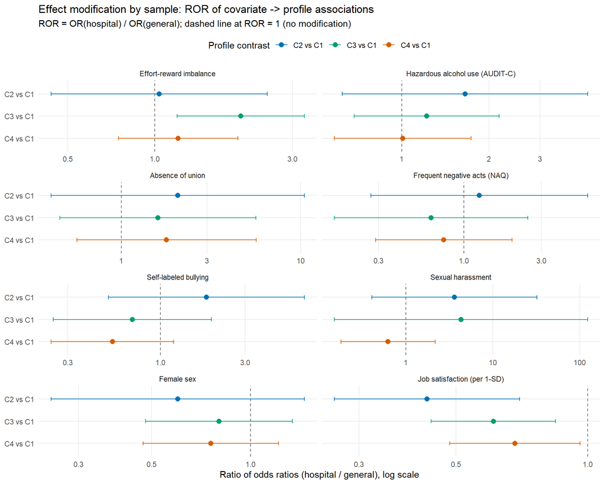

```r
## Forest of the ROR (log x-axis, reference line at 1), faceted by covariate and
## coloured by profile contrast; horizontal bars = 95% CI. Free x per panel keeps
## small-cell contrasts with very wide CIs legible. Profile levels are built from
## the actual non-reference classes so the figure follows the data-driven reference.
prof_levels <- sort(unique(ror_tbl$class))
prof_labs   <- paste0("C", prof_levels, " vs C", ref_class)
pal_base    <- c("#0072B2", "#009E73", "#D55E00", "#CC79A7", "#E69F00", "#56B4E9")
prof_pal    <- setNames(pal_base[seq_along(prof_labs)], prof_labs)

ror_plot_df <- ror_tbl |>
  dplyr::mutate(
    Profile   = factor(Profile, levels = rev(prof_labs)),
    Covariate = factor(Covariate, levels = unname(cov_labs)))

p_ror <- ggplot(ror_plot_df, aes(ROR, Profile, colour = Profile)) +
  geom_vline(xintercept = 1, linetype = "dashed", colour = "grey40") +
  geom_errorbarh(aes(xmin = ROR_lo, xmax = ROR_hi), height = 0.18) +
  geom_point(size = 2.4) +
  facet_wrap(~ Covariate, ncol = 2, scales = "free_x") +
  scale_x_log10() +
  scale_colour_manual(values = prof_pal, breaks = prof_labs) +
  labs(x = "Ratio of odds ratios (hospital / general), log scale", y = NULL,
       colour = "Profile contrast",
       title = "Effect modification by sample: ROR of covariate -> profile associations",
       subtitle = "ROR = OR(hospital) / OR(general); dashed line at ROR = 1 (no modification)") +
  theme_minimal(base_size = 11) +
  theme(legend.position = "top", panel.grid.minor = element_blank())
p_ror
```

```r
ggsave("Figure_P2_ROR.png", p_ror, width = 10, height = 8, dpi = 300, bg = "white")
```

```
`height` was translated to `width`.
```

## 4.2 Descriptive backdrop: what each sample looks like

```r
## (c1) DESCRIPTIVE: survey-weighted exposure prevalence (%) of each covariate,
## by sample. General uses the survey weight (.w); the hospital .dta carries no
## comparable weight, so .w defaults to 1 there (its column is effectively raw %).
wpct01 <- function(x, w) {
  x <- as.numeric(x); ok <- !is.na(x)
  if (!any(ok)) return(NA_real_)
  100 * sum(w[ok] * x[ok]) / sum(w[ok])
}
prev_cov <- purrr::imap_dfr(cov_labs, function(lab, key) {
  g <- combo_by[["General salaried"]]; h <- combo_by[["Hospital HCW"]]
  tibble::tibble(
    Covariate = lab,
    `General salaried (%)` = round(wpct01(g[[key]], sw_of(g)), 1),
    `Hospital HCW (%)`     = round(wpct01(h[[key]], sw_of(h)), 1))
})
prev_cov |>
  knitr::kable("markdown",
    caption = "Both-samples description (1): weighted prevalence (%) of the 7 exposures by sample (1 = exposed). General salaried is survey-weighted; Hospital HCW is unweighted (no survey weight in the .dta). This is the raw exposure mix in which any effect modification sits.")

## (c2) DESCRIPTIVE: shared-profile prevalence (%) by sample, from the invariant
## 4-class model (same object used for the ORs), via group_prev().
prev_prof <- as.data.frame(round(100 * group_prev(g4_inv, gl), 1))
prev_prof$Sample <- rownames(prev_prof)
prev_prof <- prev_prof |> dplyr::select(Sample, dplyr::everything())
prev_prof |>
  knitr::kable("markdown",
    caption = "Both-samples description (2): prevalence (%) of the SHARED latent profiles C1-C4 by sample (invariant four-class model). Rows are the two samples; a different profile mix reshapes the marginal cells that feed each sample's covariate ORs.")
```

Both-samples description (1): weighted prevalence (%) of the 7 exposures by sample (1 = exposed). General salaried is survey-weighted; Hospital HCW is unweighted (no survey weight in the .dta). This is the raw exposure mix in which any effect modification sits.

| Covariate | General salaried (%) | Hospital HCW (%) |
| --- | --- | --- |
| Effort-reward imbalance | 38.5 | 55.8 |
| Hazardous alcohol use (AUDIT-C) | 26.9 | 23.9 |
| Absence of union | 63.5 | 3.9 |
| Frequent negative acts (NAQ) | 6.5 | 8.8 |
| Self-labeled bullying | 5.6 | 19.5 |
| Sexual harassment | 1.3 | 7.4 |
| Female sex | 40.4 | 70.3 |
| Job satisfaction (per 1-SD) | 1486.5 | 1976.2 |

Both-samples description (2): prevalence (%) of the SHARED latent profiles C1-C4 by sample (invariant four-class model). Rows are the two samples; a different profile mix reshapes the marginal cells that feed each sample’s covariate ORs.

|  | Sample | C1 | C2 | C3 | C4 |
| --- | --- | --- | --- | --- | --- |
| General salaried | General salaried | 26.4 | 18.1 | 27.8 | 27.7 |
| Hospital HCW | Hospital HCW | 23.5 | 3.6 | 33.1 | 39.7 |

```r
## Dynamic multiplicity read-out (Kaufman & MacLehose): how many of the contrasts
## are flagged vs how many are expected by chance at alpha = .05.
n_contrast <- sum(!is.na(ror_tbl$p_Q))
n_flag     <- sum(ror_tbl$flag == "*", na.rm = TRUE)
exp_false  <- 0.05 * n_contrast
flagged    <- ror_tbl |> dplyr::filter(flag == "*") |>
  dplyr::mutate(lab = sprintf("%s (C%d vs C%d): ROR = %.2f, p = %s",
                Covariate, class, ref_class, ROR,
                ifelse(p_Q < 0.001, "<0.001", sprintf("%.3f", p_Q))))

cat(sprintf(paste0(
  "- **Contrasts tested:** %d covariate x profile ROR/Cochran-Q tests (up to 8 covariates x 3 non-reference profiles).\n",
  "- **Flagged (p < 0.05):** %d of %d; **~%.1f** false positives are expected by chance alone at alpha = 0.05, so isolated flags are read descriptively, not as confirmatory interactions.\n",
  "%s",
  "- **ROR = 1 means no modification on the OR scale.** Relative-scale homogeneity here does not license additive (risk-difference) homogeneity, and vice versa (Kaufman & MacLehose, 2013).\n",
  "- **Small toxic-class cells** widen the OR/ROR CIs and sap Q's power; those contrasts are read directionally (sign and size of the ROR), not by their p-value.\n"),
  n_contrast, n_flag, n_contrast, exp_false,
  if (nrow(flagged)) paste0("- **Which:** ", paste(flagged$lab, collapse = "; "), ".\n")
  else "- **Which:** none reached p < 0.05.\n"))
```

[output not shown]

# Export: Table S7 values for the manuscript build

```r
readr::write_csv(dplyr::mutate(em_tbl, n_init = n_init), "tableS7_ror_formatted.csv")
ror_tbl |>
  dplyr::select(Covariate, covariate, class, Profile,
                OR_gen, lo_gen, hi_gen, OR_hosp, lo_hosp, hi_hosp,
                ROR, ROR_lo, ROR_hi, Q, df, p_Q, I2, flag) |>
  dplyr::mutate(n_init = n_init) |>
  readr::write_csv("tableS7_ror_values.csv")
cat(sprintf("Wrote tableS7_ror_formatted.csv + tableS7_ror_values.csv (%d contrasts, n_init = %d).\n",
            nrow(ror_tbl), n_init))
```

```
Wrote tableS7_ror_formatted.csv + tableS7_ror_values.csv (24 contrasts, n_init = 4000).
```

# 5. Adjusted ML three-step: mutual adjustment of all 8 covariates

The unadjusted per-sample ORs in Section 3 treat each covariate independently. This section fits a single **mutually adjusted** ML three-step model per sample, entering all 8 covariates simultaneously. Because the hospital sample has a small class (C2 ≈ 3.6 %), which can cause near-separation and coefficient inflation, the estimator uses a ridge (L2) penalty as fallback: the unpenalised model (λ = 0) is attempted first; if any |β| > 5 or the Hessian is singular, the model is re-fitted with λ = 0.1. At λ = 0 the estimator is identical to the standard ML three-step (Vermunt 2010); at λ > 0 coefficients shrink toward zero — ORs remain interpretable but are slightly conservative.

```r
## Build the 8-column predictor matrix for each sample (complete-case on items;
## NAs in individual covariates are allowed - ml3step_multi drops rows with any NA
## in Z, so each sample uses the per-model complete case set).
gen_df_adj  <- combo[combo$setting == "General salaried", ]
hosp_df_adj <- combo[combo$setting == "Hospital HCW",    ]

## Job satisfaction: standardise within each sample's analysis set (same as Part 3).
gen_df_adj$job_sat  <- as.numeric(scale(gen_df_adj$job_sat))
hosp_df_adj$job_sat <- as.numeric(scale(hosp_df_adj$job_sat))

Z_gen  <- as.matrix(gen_df_adj[ , cov_keys])
Z_hosp <- as.matrix(hosp_df_adj[, cov_keys])

## Helper: fit with lambda=0; if |b|>5 or hessian singular, retry with lambda=0.1.
fit_adj <- function(Z, post, modal, ref, label) {
  m <- ml3step_multi(Z, post, modal, ref = ref, lambda = 0)
  need_ridge <- m$conv != 0 || anyNA(m$ors$se) || any(abs(m$ors$b) > 5, na.rm = TRUE)
  if (need_ridge) {
    message(label, ": near-separation detected (lambda=0) - refitting with lambda=0.1")
    m <- ml3step_multi(Z, post, modal, ref = ref, lambda = 0.1)
  }
  message(sprintf("%s: n_complete=%d/%d, lambda=%.1f, conv=%d",
                  label, m$n_complete, m$n_total, m$lambda, m$conv))
  m
}

adj_gen  <- fit_adj(Z_gen,  post_g, modal_g, ref = ref_class, label = "General")
```

```
General: n_complete=1832/1847, lambda=0.0, conv=0
```

```r
adj_hosp <- fit_adj(Z_hosp, post_h, modal_h, ref = ref_class, label = "Hospital")
```

```
Hospital: n_complete=862/972, lambda=0.0, conv=0
```

```r
cov_labs_adj <- c(
  eri           = "Effort-reward imbalance",
  auditc_hazard = "Hazardous alcohol use (AUDIT-C)",
  no_union      = "No union organisation",
  naq_frequent  = "Frequent negative acts (NAQ)",
  bully_self    = "Self-labelled bullying",
  sex_harass    = "Sexual harassment",
  sex_woman     = "Female sex",
  job_sat       = "Job satisfaction (per 1-SD)"
)

fmt_ci_adj <- function(or, lo, hi) sprintf("%.2f (%.2f–%.2f)", or, lo, hi)
z196 <- 1.96

## ml3step_multi stores b (log-OR) and se per row; use them directly for ROR math
## to avoid rounding drift from back-transforming the CI.
gen_adj_side  <- adj_gen$ors  |> dplyr::select(covariate, class,
  OR_gen = OR, lo_gen = lo, hi_gen = hi, b_gen = b, se_gen = se)
hosp_adj_side <- adj_hosp$ors |> dplyr::select(covariate, class,
  OR_hosp = OR, lo_hosp = lo, hi_hosp = hi, b_hosp = b, se_hosp = se)

adj_ror <- dplyr::inner_join(gen_adj_side, hosp_adj_side,
                             by = c("covariate", "class")) |>
  dplyr::mutate(
    logROR   = b_hosp - b_gen,
    seLogROR = sqrt(se_gen^2 + se_hosp^2),
    ROR      = exp(logROR),
    ROR_lo   = exp(logROR - z196 * seLogROR),
    ROR_hi   = exp(logROR + z196 * seLogROR),
    Q        = (logROR / seLogROR)^2,
    p_Q      = stats::pchisq(Q, df = 1, lower.tail = FALSE),
    I2       = pmax(0, (Q - 1) / Q) * 100,
    Covariate = unname(cov_labs_adj[covariate]),
    Profile   = paste0("C", class, " vs C", ref_class)
  ) |>
  dplyr::arrange(match(covariate, cov_keys), class) |>
  dplyr::mutate(
    p_holm = p.adjust(p_Q, method = "holm"),
    q_BH   = p.adjust(p_Q, method = "BH"),
    flag   = dplyr::case_when(
      !is.na(q_BH) & q_BH < 0.05 ~ "*†",
      !is.na(p_Q)  & p_Q  < 0.05 ~ "*",
      TRUE ~ ""))

fmt_p_adj <- function(p) ifelse(is.na(p), "—", ifelse(p < 0.001, "<0.001", sprintf("%.3f", p)))

adj_em_tbl <- adj_ror |>
  dplyr::transmute(
    Covariate,
    Profile,
    `OR general (95% CI)`  = fmt_ci_adj(OR_gen,  lo_gen,  hi_gen),
    `OR hospital (95% CI)` = fmt_ci_adj(OR_hosp, lo_hosp, hi_hosp),
    `ROR (95% CI)`         = paste0(fmt_ci_adj(ROR, ROR_lo, ROR_hi), flag),
    `Cochran Q (df=1)`     = sprintf("%.2f", Q),
    `p-value`              = fmt_p_adj(p_Q),
    `p (Holm)`             = fmt_p_adj(p_holm),
    `q (BH)`               = fmt_p_adj(q_BH),
    `I² (%)`               = sprintf("%.0f", I2)
  )

adj_em_tbl |>
  kableExtra::kbl(
    format  = "html",
    caption = sprintf(
      "Table S8. Effect modification by sample — adjusted ML three-step ORs (95%% CI) mutually adjusting for all 8 covariates, ROR = OR(hospital)/OR(general), Cochran Q (df=1), Holm p, BH q, and I&sup2;. Reference = C%d %s. General: &lambda;=%.1f, n=%d/%d. Hospital: &lambda;=%.1f, n=%d/%d.",
      ref_class, lab_inv[ref_class],
      adj_gen$lambda,  adj_gen$n_complete,  adj_gen$n_total,
      adj_hosp$lambda, adj_hosp$n_complete, adj_hosp$n_total),
    align  = c("l","l","r","r","r","r","r","r","r","r"),
    escape = FALSE) |>
  kableExtra::kable_styling(
    bootstrap_options = c("striped","hover","condensed"),
    full_width = FALSE, font_size = 12) |>
  kableExtra::column_spec(5, bold = adj_ror$flag != "") |>
  kableExtra::footnote(
    general = paste0(
      "* nominal p &lt; 0.05; *&dagger; nominal p &lt; 0.05 AND BH q &lt; 0.05. ",
      "p&nbsp;(Holm): step-down FWER correction. q&nbsp;(BH): Benjamini-Hochberg FDR. ",
      "Both applied across all ", nrow(adj_ror), " contrasts. ",
      "&lambda; = 0: standard ML three-step; &lambda; = 0.1: L2 ridge fallback for near-separation. ",
      "Job satisfaction z-standardised within each sample (OR per 1-SD). ",
      "Small hospital class (C2 &asymp;3.6%) widens CIs and lowers Q power for those rows."),
    general_title = "Note. ",
    footnote_as_chunk = TRUE,
    escape = FALSE)
```

Table S8. Effect modification by sample — adjusted ML three-step ORs (95% CI) mutually adjusting for all 8 covariates, ROR = OR(hospital)/OR(general), Cochran Q (df=1), Holm p, BH q, and I². Reference = C1 Strong constructive. General: λ=0.0, n=1832/1847. Hospital: λ=0.0, n=862/972.

| Covariate | Profile | OR general (95% CI) | OR hospital (95% CI) | ROR (95% CI) | Cochran Q (df=1) | p-value | p (Holm) | q (BH) | I² (%) |
| --- | --- | --- | --- | --- | --- | --- | --- | --- | --- |
| Effort-reward imbalance | C2 vs C1 | 1.10 (0.78–1.56) | 0.60 (0.23–1.59) | 0.55 (0.19–1.53) | 1.32 | 0.251 | 1.000 | 0.669 | 24 |
| Effort-reward imbalance | C3 vs C1 | 0.84 (0.60–1.17) | 1.78 (1.14–2.79) | 2.12 (1.21–3.70)* | 6.93 | 0.008 | 0.203 | 0.105 | 86 |
| Effort-reward imbalance | C4 vs C1 | 2.30 (1.67–3.16) | 2.38 (1.50–3.77) | 1.03 (0.59–1.81) | 0.01 | 0.905 | 1.000 | 0.998 | 0 |
| Hazardous alcohol use (AUDIT-C) | C2 vs C1 | 1.22 (0.83–1.79) | 1.30 (0.46–3.66) | 1.07 (0.35–3.23) | 0.01 | 0.908 | 1.000 | 0.998 | 0 |
| Hazardous alcohol use (AUDIT-C) | C3 vs C1 | 1.76 (1.26–2.46) | 1.73 (1.02–2.92) | 0.98 (0.53–1.83) | 0.00 | 0.953 | 1.000 | 0.998 | 0 |
| Hazardous alcohol use (AUDIT-C) | C4 vs C1 | 1.70 (1.19–2.43) | 1.07 (0.62–1.88) | 0.63 (0.33–1.22) | 1.85 | 0.174 | 1.000 | 0.522 | 46 |
| No union organisation | C2 vs C1 | 2.16 (1.54–3.04) | 2.12 (0.40–11.35) | 0.98 (0.18–5.44) | 0.00 | 0.982 | 1.000 | 0.998 | 0 |
| No union organisation | C3 vs C1 | 1.17 (0.87–1.56) | 1.01 (0.28–3.67) | 0.87 (0.23–3.24) | 0.04 | 0.833 | 1.000 | 0.998 | 0 |
| No union organisation | C4 vs C1 | 1.36 (1.00–1.85) | 0.99 (0.29–3.40) | 0.73 (0.20–2.60) | 0.24 | 0.626 | 1.000 | 0.939 | 0 |
| Frequent negative acts (NAQ) | C2 vs C1 | 1.62 (0.70–3.75) | 1.62 (0.26–10.19) | 1.00 (0.13–7.58) | 0.00 | 0.998 | 1.000 | 0.998 | 0 |
| Frequent negative acts (NAQ) | C3 vs C1 | 1.12 (0.45–2.76) | 0.69 (0.20–2.35) | 0.62 (0.13–2.84) | 0.38 | 0.536 | 1.000 | 0.939 | 0 |
| Frequent negative acts (NAQ) | C4 vs C1 | 1.70 (0.81–3.61) | 1.48 (0.52–4.19) | 0.87 (0.24–3.13) | 0.05 | 0.828 | 1.000 | 0.998 | 0 |
| Self-labelled bullying | C2 vs C1 | 0.60 (0.24–1.50) | 0.82 (0.22–3.10) | 1.39 (0.28–6.96) | 0.16 | 0.692 | 1.000 | 0.977 | 0 |
| Self-labelled bullying | C3 vs C1 | 0.99 (0.42–2.34) | 0.74 (0.38–1.45) | 0.75 (0.25–2.22) | 0.28 | 0.598 | 1.000 | 0.939 | 0 |
| Self-labelled bullying | C4 vs C1 | 1.61 (0.78–3.33) | 1.10 (0.59–2.07) | 0.69 (0.26–1.80) | 0.58 | 0.444 | 1.000 | 0.939 | 0 |
| Sexual harassment | C2 vs C1 | 0.39 (0.04–4.19) | 1.13 (0.19–6.74) | 2.90 (0.15–56.34) | 0.50 | 0.482 | 1.000 | 0.939 | 0 |
| Sexual harassment | C3 vs C1 | 0.23 (0.02–3.64) | 0.76 (0.29–2.00) | 3.22 (0.18–58.96) | 0.62 | 0.430 | 1.000 | 0.939 | 0 |
| Sexual harassment | C4 vs C1 | 1.71 (0.45–6.52) | 1.06 (0.43–2.65) | 0.62 (0.12–3.15) | 0.33 | 0.566 | 1.000 | 0.939 | 0 |
| Female sex | C2 vs C1 | 1.23 (0.89–1.69) | 0.59 (0.23–1.54) | 0.48 (0.18–1.32) | 2.01 | 0.156 | 1.000 | 0.522 | 50 |
| Female sex | C3 vs C1 | 1.14 (0.85–1.52) | 0.75 (0.46–1.21) | 0.66 (0.38–1.15) | 2.17 | 0.140 | 1.000 | 0.522 | 54 |
| Female sex | C4 vs C1 | 1.12 (0.83–1.52) | 0.63 (0.39–1.03) | 0.56 (0.32–1.00)* | 3.85 | 0.050 | 1.000 | 0.279 | 74 |
| Job satisfaction (per 1-SD) | C2 vs C1 | 0.38 (0.32–0.47) | 0.19 (0.12–0.31) | 0.49 (0.29–0.84)* | 6.88 | 0.009 | 0.203 | 0.105 | 85 |
| Job satisfaction (per 1-SD) | C3 vs C1 | 0.67 (0.56–0.79) | 0.47 (0.34–0.64) | 0.70 (0.49–1.00) | 3.83 | 0.050 | 1.000 | 0.279 | 74 |
| Job satisfaction (per 1-SD) | C4 vs C1 | 0.35 (0.29–0.42) | 0.24 (0.18–0.33) | 0.70 (0.48–1.01) | 3.59 | 0.058 | 1.000 | 0.279 | 72 |

Note. * nominal p < 0.05; *† nominal p < 0.05 AND BH q < 0.05. p (Holm): step-down FWER correction. q (BH): Benjamini-Hochberg FDR. Both applied across all 24 contrasts. λ = 0: standard ML three-step; λ = 0.1: L2 ridge fallback for near-separation. Job satisfaction z-standardised within each sample (OR per 1-SD). Small hospital class (C2 ≈3.6%) widens CIs and lowers Q power for those rows.